# Econ_490_PS3_dcstein2

Danny Stein

4/4/2022

# Question 1

## Part a

**Answer:**The model that has the smallest training RSS is best subset selection because it’s a model with k predictors. This is due to the fact that RSS of best subset selection will always decrease as the number of k predictors approaches p. Using training data, we will always end up with the full model, hence the lowest training RSS.

## Part b

**Answer:**There is no straigtforward answer for which model produces the lowest test MSE.

## Part c

*I*

**Answer:**True- THe model with (k+1) predictors are obtained by adding one additional variable at a time that leads to the greatest improvement in the model.

*II*

**Answer:**True-The model with k predictors is rendered through the removal of one predictor at a time from the (k+1) variable model.

*III*

**Answer:**False- Adding or elminating a variable in a model may consequently remove any other variables that do not improve the model fit.

*IV*

**Answer:**False-There is no direct relationship between variables selected in either forward or backward stepwise selection.

*V*

**Answer:**False-The model that contains (K+1) predictors is obtained by selecting all possible models with (k+1) predictors, which does not mean the model will contain the k-variable model.

#Question 2

## Part a

**Answer:**The lasso, relative to OLS has a lower variance than OLS and will give improved prediction accuracy when its increase in bias is less than its decrease in variance.

##Part b

**Answer:**The ridge regression compared to OLS is the same as the Lasso. There will be improved prediction accuracy when its increase in bias is less than than the decrease in variance of f(x).

## Part c

**Answer:**Non-linear models compared to OLS are more flexible and will have improved prediction accuracy when the increase in variance of f(x) is less than the decrease in bias.

# Question 3

## Part a

**Answer:**The training MSE will steadily increase as the tuning parameter increases since the flexibility of the model is drastically reduced.

## Part b

**Answer:** The test RSS will decrease initially as flexibility decreases, however, then test RSS increases because the bias increases larger than the decrease in variance of f(x).

## Part c

**Answer:** Variance will decrease steadily as the tuning parameter approaches $\infty$ since the ridge regression coefficients approach zero.

## Part d

**Answer:** For squared bias, as the tuning parameter increases, the bias will steadily increase because the shrinkage parameter casues the coefficients to become significantly underestimated.

## Part e

**Answer:** The irreducible error is independent of the model and thus is always constant.

# Question 4

## part a

```r
college <- read.csv("C:/Users/dcste/OneDrive/Senior_Year_Second_Semester/Econ_490/Homework/Econ_490_HW/College.csv", header = T)
set.seed(30)
rownames(college) <- college[,1]
college <- college[,-1]
train <- sample(nrow(college), ceiling((nrow(college))/2))
training_data <- college[train,]
testing_data <- college[-train,]
```

## Part b

```r
lm_fit <- lm(Apps~.,data = training_data)
summary(lm_fit)
```

```
##
## Call:
## lm(formula = Apps ~ ., data = training_data)
##
## Residuals:
##     Min      1Q  Median      3Q     Max
## -4063.8  -473.4   -28.0   348.3  7465.4
##
## Coefficients:
##               Estimate Std. Error t value Pr(>|t|)
## (Intercept) -158.45293  604.29745  -0.262  0.79330
## PrivateYes  -650.32700  207.26605  -3.138  0.00184 **
## Accept         1.72573    0.05010  34.445  < 2e-16 ***
## Enroll        -1.07269    0.24136  -4.444 1.17e-05 ***
## Top10perc     59.29408    8.02597   7.388 9.96e-13 ***
## Top25perc    -17.72151    6.50626  -2.724  0.00676 **
## F.Undergrad    0.03741    0.04237   0.883  0.37785
## P.Undergrad    0.07477    0.07031   1.063  0.28831
## Outstate      -0.07141    0.02923  -2.443  0.01503 *
## Room.Board     0.15510    0.07556   2.053  0.04081 *
## Books          0.36808    0.38774   0.949  0.34308
## Personal      -0.03144    0.09232  -0.341  0.73362
## PhD           -9.88820    6.96479  -1.420  0.15652
## Terminal      -4.19191    7.80086  -0.537  0.59134
## S.F.Ratio     15.17976   19.47743   0.779  0.43627
## perc.alumni    5.06825    5.92742   0.855  0.39307
## Expend         0.03475    0.01790   1.941  0.05296 .
## Grad.Rate      7.23176    4.36609   1.656  0.09850 .
## ---
## Signif. codes:  0 '***' 0.001 '**' 0.01 '*' 0.05 '.' 0.1 ' ' 1
##
## Residual standard error: 1081 on 371 degrees of freedom
## Multiple R-squared:  0.9404, Adjusted R-squared:  0.9377
## F-statistic: 344.6 on 17 and 371 DF,  p-value: < 2.2e-16
```

```r
# Calculating Test Error
attach(college)
test_error <- mean((Apps - predict(lm_fit,testing_data))^2)
cat("The test error is",round(test_error))
```

```
## The test error is 26091386
```

## Part c

Fit a ridge regression on the training data with the tuning parameter chosen by cross-validation.

```r
library(glmnet)
set.seed(30)
x <- model.matrix(Apps~.,college)[,-1]
y <- Apps
```

```r
set.seed(30)
train_1 <- sample(1:nrow(x), nrow(x) /2)
test <- (-train_1)
y.test <- y[test]

grid <- 10^(seq(-2,10, length.out = 100))
ridge <- glmnet(x[train_1,],y[train_1],alpha = 0, lambda = grid, thresh = 1e-12)
cv_lam <- cv.glmnet(x[train_1,], y[train_1], alpha = 0)
# Selecting the best lambda

best_lambda <- cv_lam$lambda.min
cat("The lambda corresponding to the smallest test error is", round(best_lambda))
```

```
## The lambda corresponding to the smallest test error is 409
```

```r
# Calculating test mse with lambda = 409

ridge_pred <- predict(ridge, s = best_lambda, newx = x[test, ])
ridge$lambda[62]
```

```
## [1] 403.7017
```

```r
coef(ridge)[,62]
```

```
##   (Intercept)    PrivateYes        Accept        Enroll     Top10perc
## -1.576838e+03 -5.693472e+02  1.152396e+00  2.659348e-01  3.048520e+01
##     Top25perc   F.Undergrad   P.Undergrad      Outstate    Room.Board
##  1.375892e-01  6.000849e-02  3.241825e-02 -2.491276e-02  2.241228e-01
##         Books      Personal           PhD      Terminal     S.F.Ratio
##  4.838217e-01 -7.468254e-02 -5.532798e+00 -5.819826e+00  2.082260e+01
##   perc.alumni        Expend     Grad.Rate
## -3.631658e+00  4.907220e-02  1.069172e+01
```

```r
test_mse <- mean((ridge_pred-y.test)^2)


cat("The test MSE associated with this lamda is",round(test_mse))
```

```
## The test MSE associated with this lamda is 990300
```

## Part D

```r
set.seed(30)
lasso_mod <- glmnet(x[train_1,], y[train_1], alpha = 1, lambda = grid)
lam_cv <- cv.glmnet(x[train_1,], y[train_1], alpha = 1)
lam_best <- lam_cv$lambda.min
lasso_pred <- predict(lasso_mod,s = lam_best, newx = x[test,])

lasso_mse <- mean((lasso_pred-y.test)^2)
predict(lasso_mod, s = lam_best, type = "coefficients")[1:18,]
```

```
##   (Intercept)    PrivateYes        Accept        Enroll     Top10perc
## -202.49813051 -632.02649003    1.71785655   -0.98581947   57.51532872
##     Top25perc   F.Undergrad   P.Undergrad      Outstate    Room.Board
##  -16.53936320    0.02734612    0.07602199   -0.06791049    0.15368426
##         Books      Personal           PhD      Terminal     S.F.Ratio
##    0.34029241   -0.02964419   -9.66428056   -4.00647538   14.72006557
##   perc.alumni        Expend     Grad.Rate
##    4.31461733    0.03409738    6.96433172
```

```r
cat("The test mse associated with the Lasso regression is",round(lasso_mse),",and there are 17 non-zero coefficients.")
```

```
## The test mse associated with the Lasso regression is 1104695 ,and there are 17 non-zero coefficients.
```

# Question 5

## Part a

```r
set.seed(1)

X <- rnorm(100)
noise <- rnorm(100)
```

##Part b

```r
# Generating vector Y
set.seed(1)
Y <- 1 + 1*X +2*(X^2) - 6*(X^3) + noise
```

## Part C

```r
library(leaps)
set.seed(1)

data1 <- data.frame(Y,X)
model <- regsubsets(Y~poly(X,10), data = data1, nvmax = 10)
reg_summary <- summary(model)
```

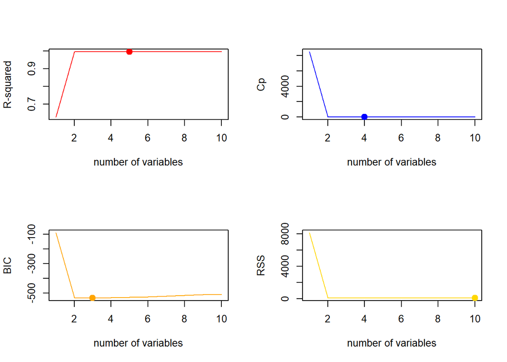

```r
par(mfrow = c(2,2))
plot(reg_summary$adjr2, xlab = "number of variables", type = "l", ylab = "R-squared", col = "red")
points(5, reg_summary$adjr2[5],col = "red", cex = 2, pch = 20)
plot(reg_summary$cp, xlab = "number of variables", type = "l", ylab = "Cp", col = "blue")
points(4,reg_summary$cp[4],col = "blue", cex = 2, pch = 20)
plot(reg_summary$bic, xlab = "number of variables", type = "l", ylab = "BIC", col = "orange")
points(3,reg_summary$bic[3], col = "orange", cex = 2, pch = 20)
plot(reg_summary$rss, xlab = "number of variables", type = "l", ylab = "RSS", col = "gold")
points(10, reg_summary$rss[10], col = "gold", cex = 2, pch = 20)
```

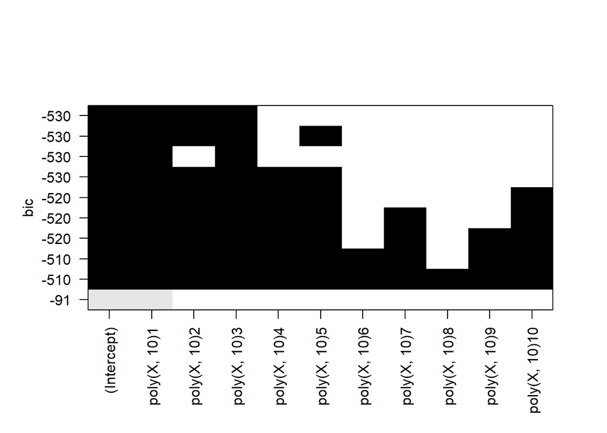

```r
plot(model, scale = "bic")
```

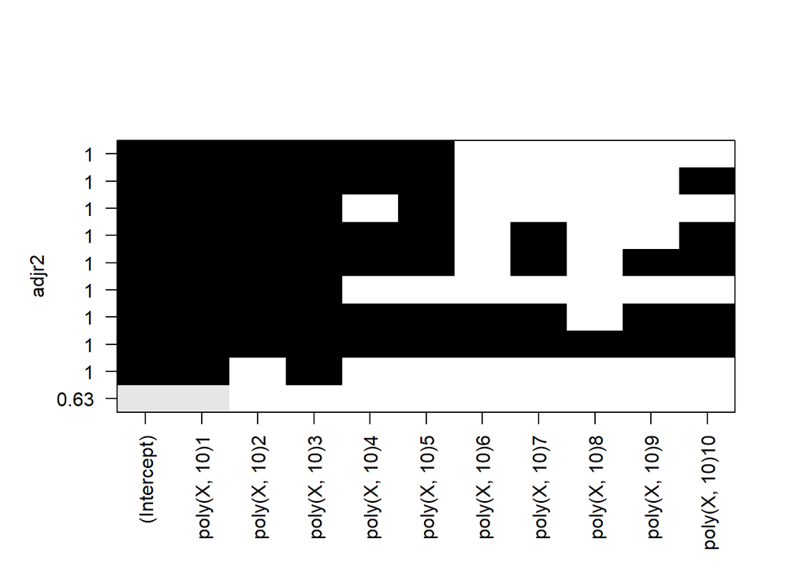

```r
plot(model, scale = "adjr2")
```

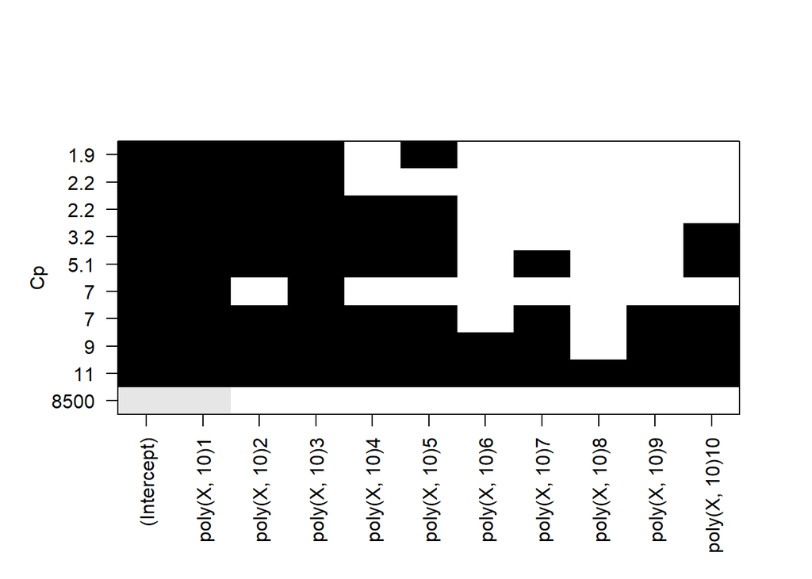

```r
plot(model, scale = "Cp")
```

```r
#Select model with lowest bic indicates a third-degree polynomial equation.
coef(model,3)
```

```
##  (Intercept) poly(X, 10)1 poly(X, 10)2 poly(X, 10)3
##     1.428367  -117.920532     2.537915   -89.575027
```

## Part d

```
## (Intercept)    data_set          V3          V4
##   1.0615072   0.9752803   1.8762090  -5.9823614
```

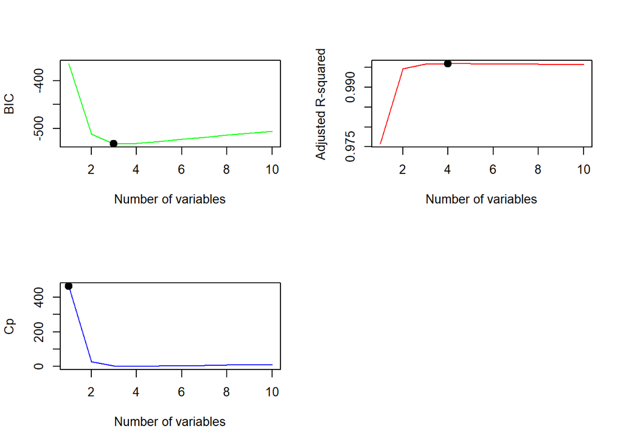

```r
#model with forward selection
set.seed(1)
data_set <- X
for (i in 2:10){
  data_set <- cbind(data_set, X^i)
}
data_set <- data.frame(cbind(Y,data_set))
model_fwd <- regsubsets(Y~.,data = data_set, nvmax = 10, method = "forward")
fwd_summary <- summary(model_fwd)

par(mfrow = c(2,2))
plot(fwd_summary$bic,col = "green", xlab = "Number of variables", type = "l",ylab = "BIC")
points(which.min(fwd_summary$bic), fwd_summary$bic[which.min(fwd_summary$bic)], cex = 2, pch =20)


plot(fwd_summary$adjr2,col = "red", xlab = "Number of variables", type = "l", ylab = "Adjusted R-squared")
points(which.max(fwd_summary$adjr2), fwd_summary$adjr2[which.max(fwd_summary$adjr2)], cex = 2, pch =20)


plot(fwd_summary$cp,col = "blue", xlab = "Number of variables", type = "l", ylab = "Cp")
points(which.max(fwd_summary$cp), fwd_summary$cp[which.max(fwd_summary$cp)], cex = 2, pch =20)

coef(model_fwd, 3)
```

```
## (Intercept)    data_set          V4          V5          V7          V9
##  1.41539927  1.11046541 -6.05236615  1.59460157 -0.46659252  0.04405208
```

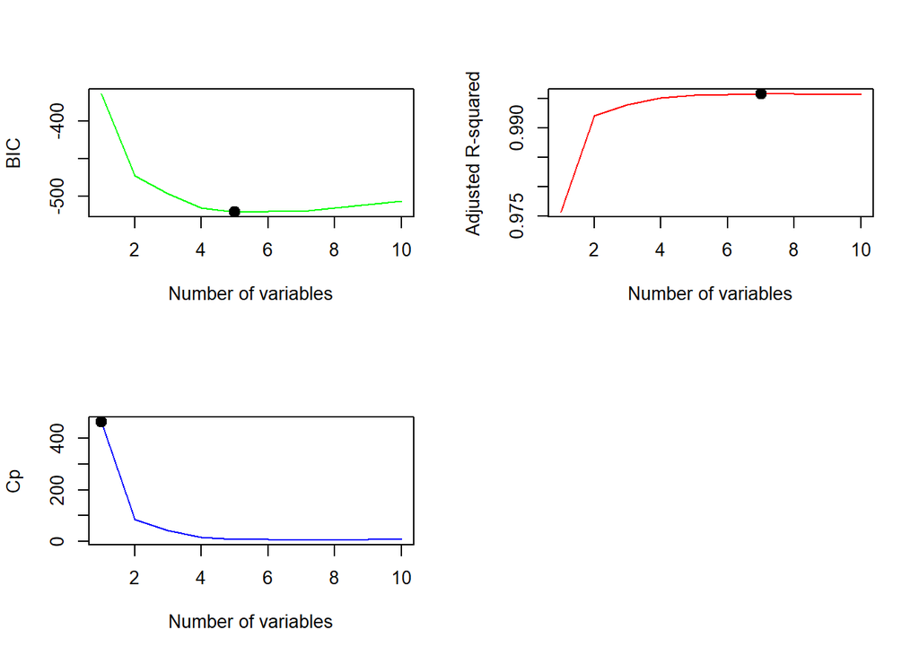

```r
model_bwd <- regsubsets(Y~.,data = data_set, nvmax = 10, method = "backward")
bwd_summary <- summary(model_bwd)

par(mfrow = c(2,2))
plot(bwd_summary$bic,col = "green", xlab = "Number of variables", type = "l",ylab = "BIC")
points(which.min(bwd_summary$bic), bwd_summary$bic[which.min(bwd_summary$bic)], cex = 2, pch =20)


plot(bwd_summary$adjr2,col = "red", xlab = "Number of variables", type = "l", ylab = "Adjusted R-squared")
points(which.max(bwd_summary$adjr2), bwd_summary$adjr2[which.max(bwd_summary$adjr2)], cex = 2, pch =20)


plot(bwd_summary$cp,col = "blue", xlab = "Number of variables", type = "l", ylab = "Cp")
points(which.max(bwd_summary$cp), bwd_summary$cp[which.max(bwd_summary$cp)], cex = 2, pch =20)

#For backward selection, the lowest BIC is with 5 variables

coef(model_bwd, 5)
```

**Answer:* Compared to my results in part c, the backward selection rendered 5 variables whereas both foward and best subset selection rendered 3 variables based on the lowest BIC.

## Part E

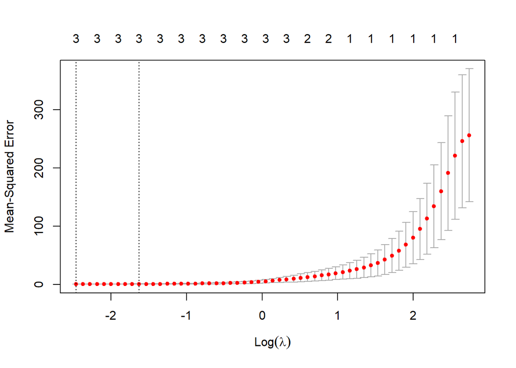

```r
#Generating a Lasso Model with 10 independent variables

set.seed(1)

grid_data <- 10^(seq(-2,10, length = 100))
train_data <- sample(1:nrow(data_set), nrow(data_set) /2)
test_data <- -train_data
y_test_data <- Y[test_data]

X_vector <- model.matrix(Y~., data = data_set)[,-1]


CV_out <- cv.glmnet(X_vector[train_data,],data_set$Y[train_data], alpha = 1)
plot(CV_out)
```

```r
lass_model <- glmnet(X_vector,data_set$Y, alpha = 1, lambda = grid_data)
```

```r
lambda_min <- CV_out$lambda.min
lambda_min
```

```
## [1] 0.08494691
```

```r
predict(lass_model, s = lambda_min, type = "coefficients")
```

```
## 11 x 1 sparse Matrix of class "dgCMatrix"
##                        s1
## (Intercept)  1.2160882002
## data_set     0.1638319550
## V3           1.6416951104
## V4          -5.4812701748
## V5           0.0307011351
## V6          -0.0558653672
## V7           0.0005833926
## V8           .
## V9           .
## V10          .
## V11          .
```

**Answer:** The resulting coefficient estimates that minimize the cross validation error are

$Y = 1.216 + 0.1638X + 1.6416X^2-5.4812X^3+0.0307X^4-.05586X^5+0.000583X^6$

The Lasso regression estimates are not similar to my step wise regression estimates, however we can see that a few coefficients are are zero.

## Part F

```r
set.seed(20)
Y_2 <- 1.5 + 3*(X)^7

colnames(X_vector) <- paste("X",1:ncol(X_vector),sep = "")
Y_df <- data.frame(cbind(Y_2,X_vector))
```

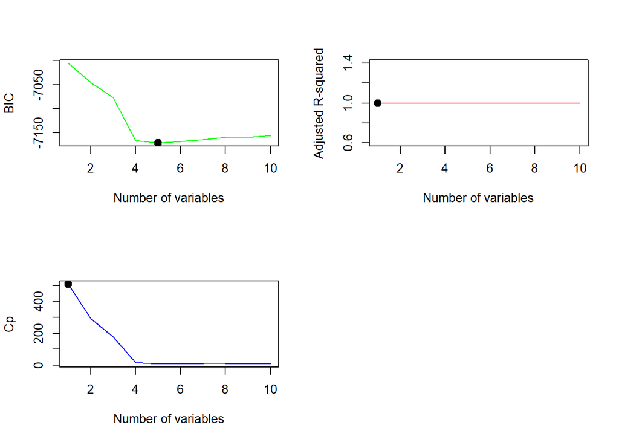

```r
reg_sub <- regsubsets(Y_2~.,data = Y_df, nvmax = 10)
reg_summary <- summary(reg_sub)

par(mfrow = c(2,2))
plot(reg_summary$bic,col = "green", xlab = "Number of variables", type = "l",ylab = "BIC")
points(which.min(reg_summary$bic), reg_summary$bic[which.min(reg_summary$bic)], cex = 2, pch =20)


plot(reg_summary$adjr2,col = "red", xlab = "Number of variables", type = "l", ylab = "Adjusted R-squared")
points(which.max(reg_summary$adjr2), reg_summary$adjr2[which.max(reg_summary$adjr2)], cex = 2, pch =20)


plot(reg_summary$cp,col = "blue", xlab = "Number of variables", type = "l", ylab = "Cp")
points(which.max(reg_summary$cp), reg_summary$cp[which.max(reg_summary$cp)], cex = 2, pch =20)
```

```r
coef(reg_sub,which.min(reg_summary$bic))
```

```
##   (Intercept)            X1            X2            X3            X7
##  1.500000e+00 -1.940632e-13 -1.435085e-14  1.040424e-13  3.000000e+00
##            X8
##  6.992464e-16
```

```r
coef(reg_sub, which.max(reg_summary$cp))
```

```
## (Intercept)          X7
##         1.5         3.0
```

```r
coef(reg_sub, which.max(reg_summary$adjr2))
```

```
## (Intercept)          X7
##         1.5         3.0
```

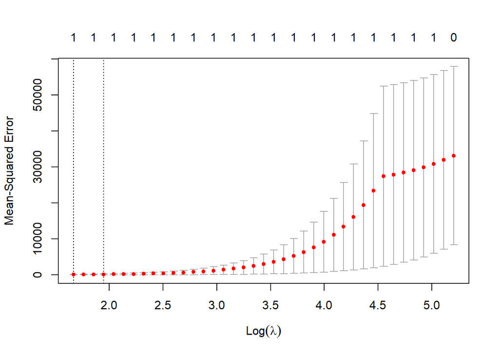

```r
#Lasso Approach

set.seed(20)

grid_3 <- 10^(seq(-2,10, length = 100))
training_3 <- sample(nrow(Y_df), nrow(Y_df)/2)
test_3 <- -training_3
test_Y <- Y_df$Y_2[test_3]

X_matrix <- model.matrix(Y_2~.,data =Y_df)[,-1]
CV_lambda <- cv.glmnet(X_matrix,Y_df$Y_2, alpha = 1)
min_cv_lambda <- CV_lambda$lambda.min

plot(CV_lambda)
```

```r
# Lasso Regression over a grid of values

Lasso_grid <- glmnet(X_vector,Y_df$Y_2,alpha = 1,lambda = grid_3)

predict(Lasso_grid, type = "coefficients", s = min_cv_lambda)
```

```
## 11 x 1 sparse Matrix of class "dgCMatrix"
##                   s1
## (Intercept) 1.869077
## X1          .
## X2          .
## X3          .
## X4          .
## X5          .
## X6          .
## X7          2.912548
## X8          .
## X9          .
## X10         .
```

The Lasso regression model correctly identified the correct model were extremely close to the true coefficient estimates.